# Homework 2 Problems

# Part I: Sampling and Experimental Design

$\bf (1)$ Define each of the following terms.

1. Explanatory variable
2. Response variable
3. Experimental study
4. Observational study
5. Survey
6. Lurking (confounding) variable
7. In one or two sentences, explain why a statistical **association** between two variables is not by itself evidence that one **causes** the other. Give an example of a lurking variable that could produce an association without a causal link.

$\bf (2)$ Name the sampling method used in each of the following situations.

1. A man stands outside a grocery store handing out questionnaires that ask shoppers to evaluate their shopping experience and the quality of the service. He does not approach shoppers whose hands are full of groceries; instead he asks every shopper who has only a few items or who has both hands free.
2. A gardener has planted 10 rows of corn in a garden box, and each row holds eight corn plants. The gardener wants to know the average height of the corn plants in the box, so he randomly selects rows 1, 5, and 9 and measures the height of every plant in those rows.
3. A company wants to know how its employees feel about compensation and benefits. Over the next few weeks, the company asks 30 employees from each of its branch locations to fill out a survey about compensation.
4. A polling company wants to know what proportion of the citizens of Moscow, Idaho, are voting for the Republican candidate in the mayoral race. The company records this information for every 5th voter who leaves the voting booth.
5. A lumber company wants to estimate the amount of usable lumber on a plot of land. The company randomly selects 100 trees and measures the diameter, height, and volume of each one in order to estimate its yield in board feet.
6. Explain the difference between **sampling error** and **nonsampling error**, and give one example of each.
7. A university emails a satisfaction survey to all 11,000 of its students, and 600 reply. The students who reply are far more likely to be the ones with a strong complaint. Name the source of bias at work here, and explain why emailing 40,000 students instead of 11,000 would **not** fix the problem.

$\bf (3)$ Name the experimental design used in each of the following situations. Choose from **completely randomized design**, **randomized block design**, and **matched pairs design**.

1. A nutritionist wants to compare three breakfast cereals. She recruits 90 volunteers and uses a random number generator to assign 30 of them to each cereal.
2. A dermatologist testing a new ointment applies the ointment to one arm of each patient and a placebo cream to that patient’s other arm, deciding at random which arm receives which.
3. An agronomist testing four fertilizers suspects that soil drainage strongly affects yield. He sorts his 40 plots into a “well-drained” group and a “poorly-drained” group, then randomly assigns the four fertilizers within each group.
4. A sleep researcher recruits 200 subjects, and a coin flip decides whether each subject receives a new sleep medication or an identical-looking pill that contains no medication.
5. For the study in part (d), identify the **experimental units**, the **factor**, the **levels** of that factor, the **treatments**, and the **control group**. Was this study **blinded**? What additional information would you need in order to know whether it was **double blinded**?
6. A study finds that students who attend more review sessions earn higher exam scores, but the review sessions were optional. Explain what **random assignment** would have allowed the researchers to conclude that this study cannot, and explain why **random sampling** alone is not enough to establish cause.

# Part II: The Normal Distribution, $z$-scores, and Outliers

$\bf (4)$ Rocket League is a popular online video game and E-sport that emerged in 2015. Players from around the world compete in sports such as soccer (football), basketball, and hockey while controlling RC-like vehicles. The most popular game mode is doubles soccer, in which two teams of two players each try to outscore the other by hitting a soccer ball into the opposing goal. Each car carries a limited supply of **boost**, which is spent to accelerate and to fly and which is replenished by driving over boost pads on the field. A player’s **boost used per minute (BPM)** measures how aggressively that player spends boost over the course of a match. The histogram below shows the distribution of BPM for $n = 5{,}714$ player-match records collected from ranked matches.

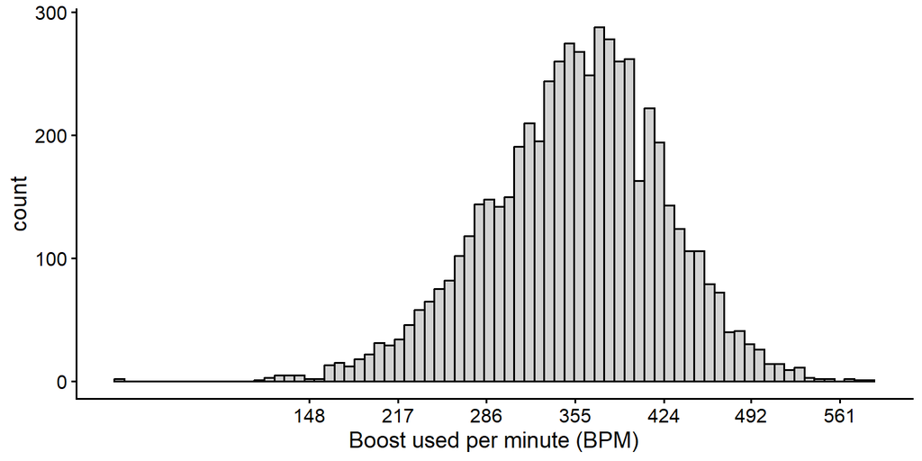

1. Assume a mean of $\bar{x} = 355$ and a standard deviation of $s = 69$. In approximately what proportion of matches did a player use more than 424 BPM?
2. In approximately what proportion of matches was the BPM greater than 217 but less than 493?
3. How much boost per minute would a player need to use in a match in order to be in the top $2.5\%$ of matches?
4. In a new match, a player records a BPM of 562. Compute the $z$-score for this match and explain what that $z$-score means in relation to the average BPM. How many standard deviations from the mean is this performance?

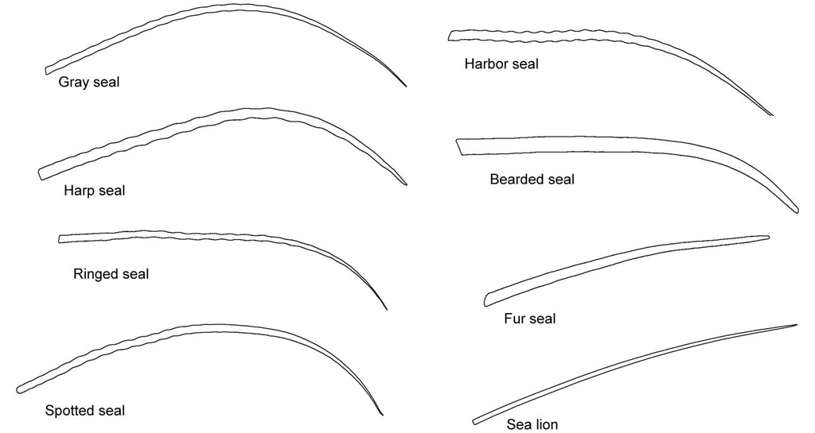

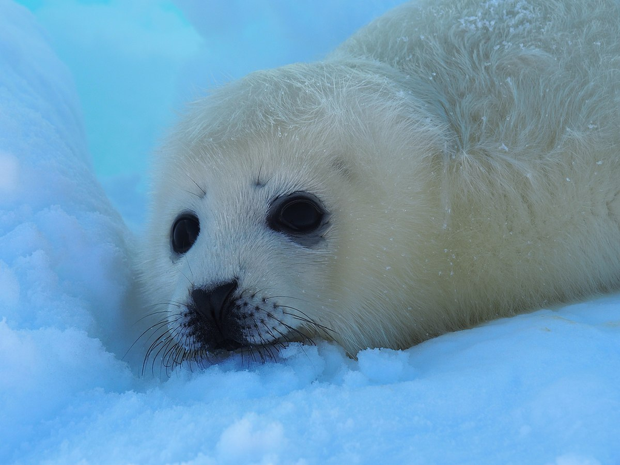

Pinniped whisker morphology - Ginter et al. 2012 (left), and a juvenile Harp Seal (right).

$\bf (5)$ Pinnipeds (seals and sea lions) possess the largest vibrissae (whiskers) among mammals, and their vibrissal hair shafts show a diversity of shapes (see **Figure 1**). In a study conducted by (Ginter et al. 2012), researchers measured 9 characteristics of Pinniped whiskers in individuals drawn from 9 species of seals and sea lions, with the goal of better characterizing whisker morphology and evolution. **Table 1** gives the recorded whisker lengths of 20 Harp Seals. The data have been sorted by increasing “Total Length (cm)” for your convenience. Use the table to answer the following questions.

Whisker Length data for $n = 20$ Harp Seals

| Observation | Whisker Total Length (cm) | Number of Beads |
| --- | --- | --- |
| 1 | 4.18 | 2 |
| 2 | 4.23 | 2 |
| 3 | 4.31 | 2 |
| 4 | 4.31 | 2 |
| 5 | 4.33 | 2 |
| 6 | 4.34 | 2 |
| 7 | 4.35 | 2 |
| 8 | 4.38 | 2 |
| 9 | 4.40 | 2 |
| 10 | 4.41 | 2 |
| 11 | 4.43 | 3 |
| 12 | 4.44 | 2 |
| 13 | 4.46 | 2 |
| 14 | 4.47 | 3 |
| 15 | 4.48 | 3 |
| 16 | 4.51 | 2 |
| 17 | 4.59 | 3 |
| 18 | 4.60 | 2 |
| 19 | 4.62 | 2 |
| 20 | 5.08 | 3 |

1. Compute the quartiles, the interquartile range, the mean, and the standard deviation of the variable “Total Length (cm)”. Use the values exactly as they appear in **Table 1**. Remember that we find the quartiles by the **median of halves** method used in class: find the median first, and when $n$ is odd, leave that median out of both halves.
2. Construct a boxplot of the variable “Total Length” and note any outliers. Use the $1.5\times IQR$ rule to decide what counts as an outlier.
3. Observation 20 has a total whisker length of 5.08 cm. How many standard deviations from the mean whisker length is this observation? (hint: compute the $z$-score for this observation)

$\bf (6)$ The pair of boxplots below was constructed from the Pinniped whisker data in **Table 1**. The boxplots show the distribution of total whisker length (cm) for whiskers with 2 beads and for whiskers with 3 beads. Use them to answer the following questions.

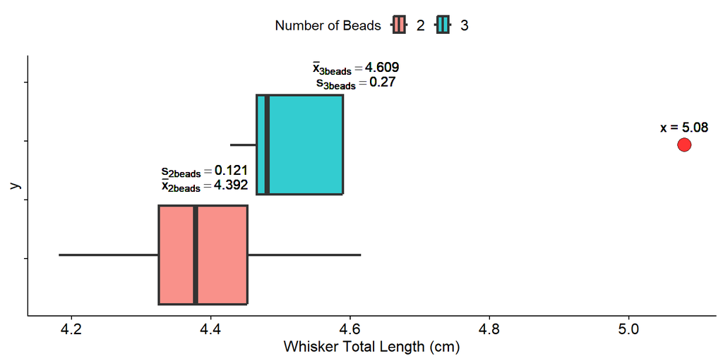

1. Using the boxplots above, do the whisker lengths for 2 bead whiskers and for 3 bead whiskers follow a normal distribution? Why or why not? Answer separately for each group.
2. Suppose researchers observe two new Harp Seals, denoted Seal 1 and Seal 2, and record the total whisker length and the number of beads for each. Seal 1 has a total whisker length of 4.32 cm on a whisker with 3 beads. Seal 2 has a total whisker length of 4.34 cm, but its whisker has only 2 beads. We want to know how the two compare *relative* to the distribution of whiskers with the same number of beads. Confirm that the whisker of Seal 1 has a $z$-score of $-1.07$ while the whisker of Seal 2 has a $z$-score of $-0.43$. Use the group means and standard deviations printed on the boxplot above.
3. Suppose the researchers observe a new whisker with 3 beads. Using the $\pm 2s$ rule, how long or how short would that whisker have to be before you would flag it as an outlier? Then look at the 3 bead group in **Table 1** and explain why the $\pm 2s$ rule should be treated with caution here. (hint: your answer to part (a) for the 3 bead group is the reason, and note that the $1.5\times IQR$ rule and the $\pm 2s$ rule do not always flag the same observations)

$\bf (7)$ According to the World Health Organization, the heights of girls aged five years are approximately normal with a mean of $\mu = 109$ cm and a standard deviation of $\sigma = 4.5$ cm. Use the empirical rule to answer parts (a) through (e). No table or calculator is needed — every number below works out evenly.

1. Give the interval, centred on the mean, that contains approximately $68\%$ of the heights. Then do the same for $95\%$ and for $99.7\%$.
2. Approximately what percentage of five-year-old girls are between $95.5$ cm and $122.5$ cm tall?
3. A five-year-old girl is $100$ cm tall. Compute her $z$-score and interpret it in one sentence.
4. Approximately what percentage of five-year-old girls are **taller** than $113.5$ cm? (hint: start from your $68\%$ interval in part (a), and remember the distribution is symmetric)
5. Would a height of $100$ cm be flagged as an outlier under the $\pm 2s$ rule? Explain.

# Part III: Probability and Discrete Random Variables

$\bf (8)$ Define each of the following terms and concepts.

1. Sample space
2. Event
3. Random trial
4. Union of two events
5. Intersection of two events
6. Disjoint (mutually exclusive) events
7. Random variable
8. Discrete random variable
9. Continuous random variable
10. Probability distribution
11. The Law of Large Numbers

$\bf (9)$ Answer the following probability questions, and show your work.

1. A fair coin is flipped 3 times. Show how to compute the probability that at least one head is observed. (hint: it is easier to find the probability of the complement first)
2. In a class of 30 students, 8 students are in band, 15 students play a sport, and 5 students are both in band and play a sport. Let $A$ be the event that a student is in band and let $B$ be the event that a student plays a sport. Draw a Venn diagram that models this situation, filling in the number of students in each region, then show how to compute the probability that a student is in band **or** plays a sport.
3. A standard deck of 52 cards contains four suits (Hearts, Diamonds, Clubs, and Spades). Each suit contains 13 cards: 9 numbered cards, 3 face cards, and an Ace. A single card is drawn at random. Show how to compute the probability that it is a numbered card, and the probability that it is the Ace of Spades.
4. An urn contains 5 green balls, 7 red balls, and 4 yellow balls. Two balls are selected at random **with replacement**. Show how to compute the probability that the first ball is yellow and the second ball is red.
5. Repeat part (d), but now assume the two balls are selected **without replacement**. Explain why your answer changed.
6. On a given day in Moscow, Idaho, the probability that it rains is $P(R) = 0.1$, the probability that it is windy is $P(W) = 0.2$, and the probability that it is cloudy is $P(C) = 0.7$. Assume these three weather events are independent. Show how to compute the probability that a given day is rainy, cloudy, **and** windy.

$\bf (10)$ A single fair coin is flipped once. Let $X = 1$ if the flip comes up heads and $X = 0$ if it comes up tails. A random variable with only these two outcomes is called a **Bernoulli** random variable, and its probability of success is $p = P(X = 1)$.

1. Write down the probability distribution of $X$ as a table of values and their probabilities.
2. Show how to compute the mean of $X$ using $\mu = \sum_x x\cdot P(x)$, and confirm that it equals $p$.
3. Show how to compute the variance of $X$ using $\sigma^2 = \sum_x (x-\mu)^2\cdot P(x)$, and confirm that it equals $p(1-p)$.
4. Now suppose the coin is bent so that it comes up heads only $30\%$ of the time. Show how to compute the mean and the variance of $X$ for this bent coin.
5. A **binomial** random variable counts the number of successes in $n$ independent Bernoulli trials. If the fair coin from parts (a)-(c) is flipped 10 times, show how to compute the mean and the variance of the number of heads. (hint: $E[X] = np$ and $Var[X] = np(1-p)$)

$\bf (11)$ Consider a survey of tree volume. Suppose that in the population of trees, $10\%$ have a volume of 10 cubic feet, $20\%$ have a volume of 20 cubic feet, $30\%$ have a volume of 30 cubic feet, and $40\%$ have a volume of 40 cubic feet. Let $X$ denote the volume of a randomly selected tree, and assume every tree has an equal chance of being selected. The probability distribution of $X$ is given in **Table 2** below.

Probability distribution of tree volume $X$

| Tree Volume (cubic feet) | $P(X)$ |
| --- | --- |
| 10 | 0.1 |
| 20 | 0.2 |
| 30 | 0.3 |
| 40 | 0.4 |

1. Verify that the four probabilities in **Table 2** form a valid probability distribution.
2. Show how to compute the mean of $X$ using $\mu = \sum_x x\cdot P(x)$, and confirm that it equals $\mu = 30$ cubic feet.
3. Show how to compute the variance of $X$ using $\sigma^2 = \sum_x (x-\mu)^2\cdot P(x)$, then take the square root and confirm that the standard deviation is $\sigma = 10$ cubic feet.
4. Is $X$, as described here, a discrete or a continuous random variable? Explain.

$\bf (12)$ Answer the following, showing the formula you used and the numbers you substituted into it.

1. An angler has a $40\%$ chance of catching a fish on every cast, and each cast is independent of the others. Using the binomial probability mass function
   $$P(X = k) = \frac{n!}{k!(n-k)!}\cdot p^k \cdot
   (1-p)^{n-k}$$
   show how to compute the probability that she catches exactly 2 fish in her next 5 casts.
2. For the angler in part (a), show how to compute the mean number of fish she expects to catch in 5 casts, and the variance. (hint: $E[X] = np$ and $Var[X] = np(1-p)$)
3. A small campus coffee stand serves an average of 3 customers per 10-minute period. Let $X$ be the number of customers in a 10-minute period, and assume $X$ follows a Poisson distribution with $\lambda = 3$. Using
   $$P(X = k) = \frac{\lambda^k\cdot
   e^{-\lambda}}{k!}$$
   show how to compute the probability that **no** customers arrive in a given 10-minute period.
4. For the coffee stand in part (c), show how to compute the probability that **at most one** customer arrives in a given 10-minute period.

# Part IV: Standard Error and the Margin of Error

$\bf (13)$ A population has a mean of $\mu = 75$ and a standard deviation of $\sigma = 12$. You repeatedly draw random samples of $n = 36$ observations from this population, and each time you record the sample mean $\bar{x}$.

1. Show how to compute the **standard error** of the sample mean, $SE = \sigma/\sqrt{n}$.
2. A classmate insists that the standard error should be 12, because that is the standard deviation of the population. Explain the mistake in their reasoning.
3. Using the $\pm 2\cdot SE$ rule from class, show how to compute the **margin of error** for $\bar{x}$, and give the interval it defines around $\mu$.
4. Show how to compute the standard error if the sample size is increased to $n = 144$. What happens to the margin of error, and why?

# References

Ginter, Carly C, Thomas J DeWitt, Frank E Fish, and Christopher D Marshall. 2012. “Fused Traditional and Geometric Morphometrics Demonstrate Pinniped Whisker Diversity.” *PloS One* 7 (4): e34481.